# Practica 2

Pierina Fernandez y Robert Cruz

2023-04-23

##ENUNCIADO

Pregunta 1:

Queremos programar un programa de tipo web scrapping con el que podamos obtener una página web, mediante su URL, y poder analizar su contenido HTML con tal de extraer datos e información específica. Nuestro programa ha de ser capaz de cumplir con los siguientes pasos:

1.1 Descargar la página web de la URL indicada, y almacenarlo en un formato de R apto para ser tratado. El primer paso para realizar tareas de crawling y scraping es poder descargar los datos de la web. Para esto usaremos la capacidad de R y de sus librerías (httr y XML) para descargar webs y almacenarlas en variables que podamos convertir en un formato fácil de analizar (p.e. de HTML a XML).

```r
library(httr)
library(XML)
```

```r
# Realizar solicitud GET a una página web
almacen <- GET("https://www.mediawiki.org/wiki/MediaWiki")

# Obtener el código de estado de la respuesta HTTP
status_code(almacen)
```

```
## [1] 200
```

```r
# Extraer el contenido de la respuesta y almacenarlo en "contenedor"
contenedor <- content(almacen, as = "text")

# Convertir a objeto HTML y almacenar en "segun_contenedor"
segun_contenedor <- htmlParse(contenedor, asText = TRUE)

# Extraer título y almacenarlo en "enlaces"
enlaces <- xpathSApply(segun_contenedor, "//title", xmlValue)

# Imprimir título
print(enlaces)
```

```
## [1] "MediaWiki"
```

1.3 Analizar el contenido de la web, buscando todos los enlaces (que en HTML se etiquetan como “a”), buscando el texto del enlace, así como la URL. Vamos a extraer, usando las funciones de búsqueda XML, todos los enlaces que salen de esta página con tal de listarlos y poder descargarlas más tarde. Sabemos que estos son elementos de tipo “a”, que tienen el atributo “href” para indicar la URL del enlace. P.e. “Texto del Enlace”. Del enlace nos quedaremos con la URL de destino y con el valor del enlace (texto del enlace).

```r
# Asigna a "enlaces_texto" el resultado de aplicar la función xpathSApply al objeto "segun_contenedor", buscando todas las etiquetas "a" y extrayendo su texto interno.
enlaces_texto <- xpathSApply(segun_contenedor, "//a", xmlValue)

# Asigna a "enlaces_url" el resultado de la fun xpathSApply al objeto "segun_contenedor", buscando  las etiquetas "a" y extrayendo el valor del atributo "href".
enlaces_url <- xpathSApply(segun_contenedor, "//a", xmlGetAttr, 'href')

# Imprime en consola el contenido de la variable "enlaces_texto".
print(enlaces_texto)
```

```
##   [1] "Jump to content"
##   [2] "Main page"
##   [3] "Get MediaWiki"
##   [4] "Get extensions"
##   [5] "Tech blog"
##   [6] "Contribute"
##   [7] "User help"
##   [8] "FAQ"
##   [9] "Technical manual"
##  [10] "Support desk"
##  [11] "Communication"
##  [12] "Developer portal"
##  [13] "Code statistics"
##  [14] "Community portal"
##  [15] "Recent changes"
```

[output cut: 150 more lines]

```r
# Imprime en consola el contenido de la variable "enlaces_url".
print(enlaces_url)
```

```
##   [1] "#bodyContent"
##   [2] "/wiki/MediaWiki"
##   [3] "/wiki/Download"
##   [4] "/wiki/Special:MyLanguage/Category:Extensions"
##   [5] "//techblog.wikimedia.org/"
##   [6] "/wiki/Special:MyLanguage/How_to_contribute"
##   [7] "/wiki/Special:MyLanguage/Help:Contents"
##   [8] "/wiki/Special:MyLanguage/Manual:FAQ"
##   [9] "/wiki/Special:MyLanguage/Manual:Contents"
##  [10] "/wiki/Project:Support_desk"
##  [11] "/wiki/Special:MyLanguage/Communication"
##  [12] "https://developer.wikimedia.org/"
##  [13] "/wiki/Development_statistics"
##  [14] "/wiki/Project:Help"
##  [15] "/wiki/Special:RecentChanges"
```

[output cut: 150 more lines]

1.4 Generar una tabla con cada enlace encontrado, indicando el texto que acompaña el enlace, y el número de veces que aparece un enlace con ese mismo objetivo. En este paso nos interesa reunir los datos obtenidos en el anterior paso. Tendremos que comprobar, para cada enlace, cuantas veces aparece.

1.5 Para cada enlace, seguirlo e indicar si está activo (podemos usar el código de status HTTP al hacer una petición a esa URL). En este paso podemos usar la función HEAD de la librería “httr”, que en vez de descargarse la página como haría GET, solo consultamos los atributos de la página o fichero destino. HEAD nos retorna una lista de atributos, y de entre estos hay uno llamado “header” que contiene más atributos sobre la página buscada. Si seguimos podemos encontrar el “status_code” en “resultado$status_code”. El “status_code” nos indica el resultado de la petición de página o fichero. Este código puede indicar que la petición ha sido correcta (200), que no se ha encontrado (404), que el acceso está restringido (403), etc. • Tened en cuenta que hay enlaces con la URL relativa, con forma “/xxxxxx/xxxxx/a.html”. En este caso, podemos indicarle como “handle” el dominio de la página que estamos tratando, o añadirle el dominio a la URL con la función “paste”. • Tened en cuenta que puede haber enlaces externos con la URL absoluta, con forma “http://xxxxxx/xxxx/a.html” (o https), que los trataremos directamente. • Tened en cuenta que puede haber enlaces que apunten a subdominios distintos, con forma “//subdominio/xxxx/xxxx/a.html”. En este caso podemos adjuntarle el prefijo “https:” delante, convirtiendo la URL en absoluta. • Tened en cuenta URLS internas con tags, como por ejemplo “#search-p”. Estos apuntan a la misma página en la que estamos, pero diferente altura de página. Equivale a acceder a la URL relativa de la misma página en la que estamos. Es recomendado poner un tiempo de espera entre petición y petición de pocos segundos (comando “Sys.sleep”), para evitar ser “baneados” por el servidor. Para poder examinar las URLs podemos usar expresiones regulares, funciones como “grep”, o mirar si en los primeros caracteres de la URL encontramos “//” o “http”. Para tratar las URLs podemos usar la ayuda de la función “paste”, para manipular cadenas de caracteres y poder añadir prefijos a las URLs si fuera necesario.

```r
# Asigna a "enlaces_texto" el resultado de aplicar la función xpathSApply al objeto "segun_contenedor", buscando todas las etiquetas "a" y extrayendo su texto interno.
enlaces_texto <- xpathSApply(segun_contenedor, "//a", xmlValue)

# Asigna a "enlaces_url" el resultado de la fun xpathSApply al objeto "segun_contenedor", buscando  las etiquetas "a" y extrayendo el valor del atributo "href".
enlaces_url <- xpathSApply(segun_contenedor, "//a", xmlGetAttr, 'href')

# Imprime en consola el contenido de la variable "enlaces_texto".
print(enlaces_texto)
```

```
##   [1] "Jump to content"
##   [2] "Main page"
##   [3] "Get MediaWiki"
##   [4] "Get extensions"
##   [5] "Tech blog"
##   [6] "Contribute"
##   [7] "User help"
##   [8] "FAQ"
##   [9] "Technical manual"
##  [10] "Support desk"
##  [11] "Communication"
##  [12] "Developer portal"
##  [13] "Code statistics"
##  [14] "Community portal"
##  [15] "Recent changes"
```

[output cut: 150 more lines]

```r
# Imprime en consola el contenido de la variable "enlaces_url".
print(enlaces_url)
```

```
##   [1] "#bodyContent"
##   [2] "/wiki/MediaWiki"
##   [3] "/wiki/Download"
##   [4] "/wiki/Special:MyLanguage/Category:Extensions"
##   [5] "//techblog.wikimedia.org/"
##   [6] "/wiki/Special:MyLanguage/How_to_contribute"
##   [7] "/wiki/Special:MyLanguage/Help:Contents"
##   [8] "/wiki/Special:MyLanguage/Manual:FAQ"
##   [9] "/wiki/Special:MyLanguage/Manual:Contents"
##  [10] "/wiki/Project:Support_desk"
##  [11] "/wiki/Special:MyLanguage/Communication"
##  [12] "https://developer.wikimedia.org/"
##  [13] "/wiki/Development_statistics"
##  [14] "/wiki/Project:Help"
##  [15] "/wiki/Special:RecentChanges"
```

[output cut: 150 more lines]

```r
# Crea  data frame  "gentabla" con columnas vacías para almacenar info sobre los enlaces.
gentabla <- data.frame(enlaces_texto = character(),
                       links_original_url = character(),
                       enlaces_url= character(),
                       links_relative = character(),
                       links_internal = character(),
                       repeticiones = numeric(),
                       scraps = character(),
                       stringsAsFactors = FALSE)


# Crea tabla  "frecuencia" para contar las veces que aparece cada valor en "enlaces_texto

frecuencia <- table(enlaces_url)

# Itera sobre valores en "enlaces_texto",pausa 1 seg, imprime msj en consola indicando completado iteracion,2 asigna el valor de "enlaces_texto[i]" a la columna "enlaces_texto" de la fila "i" de "gentabla".

for (i in 1:length(enlaces_texto)) {
  Sys.sleep(0)
  print("round done")
  gentabla[i, "enlaces_texto"] <- enlaces_texto[i]
  gentabla[i, "links_original_url"] <- enlaces_url[i]
  gentabla[i, "enlaces_url"] <- enlaces_url[i]
  gentabla[i, "links_relative"] <- "N"
  gentabla[i, "links_internal"] <- "S"
  gentabla[i, "repeticiones"] <- frecuencia[enlaces_url[i]]

  #si inicia con /wiki/
  validation_wiki <- startsWith(enlaces_url[i], "/wiki/")
  if(validation_wiki) {
    gentabla[i, "enlaces_url"] <- paste0("https://www.mediawiki.org",enlaces_url[i])
    gentabla[i, "links_relative"] <- "S"
  }

  # Verifica si el enlace URL comienza con "https:" y lo agrega a la columna "enlaces_url" de gentabla
  validation_wiki <- startsWith(enlaces_url[i], "https:")
  if(validation_wiki) {
    gentabla[i, "enlaces_url"] <- paste0("", enlaces_url[i])

    validation_internal <- startsWith(enlaces_url[i], "https://www.mediawiki.org")
    if(!validation_internal) {
      gentabla[i, "links_internal"] <- "N"
    }

  }

  #si el enlace URL comienza con "//" agrega "https:" al inicio y lo agrega a la columna "enlaces_url" de gentabla
  validation_wiki <- startsWith(enlaces_url[i], "//")
  if(validation_wiki) {
    gentabla[i, "enlaces_url"] <- paste0("https:", enlaces_url[i])
    gentabla[i, "links_relative"] <- "S"
  }

  #si URL comienza con "/w/", agrega "https://www.mediawiki.org" al inicio a la columna "enlaces_url" de gentabla
  validation_wiki <- startsWith(enlaces_url[i], "/w/")
  if(validation_wiki) {
    gentabla[i, "enlaces_url"] <- paste0("https://www.mediawiki.org", enlaces_url[i])
    gentabla[i, "links_relative"] <- "S"
  }

  # sicomienza con "#" agrega "https://www.mediawiki.org/wiki/MediaWiki" a la columna "enlaces_url" de gentabla
  validation_wiki <- startsWith(enlaces_url[i], "#")
  if(validation_wiki) {
    gentabla[i, "enlaces_url"] <- paste0("https://www.mediawiki.org/wiki/MediaWiki", enlaces_url[i])
    gentabla[i, "links_relative"] <- "S"
  }

  # Imprime  valor de  variable enlaces_url[i] precedido por "TEST> "
  print(paste0("TEST> " , enlaces_url[i]))


  # solicitud HEAD al enlace URL de la celda i de la columna "enlaces_url" de gentabla
  code <- status_code(HEAD(gentabla[i, "enlaces_url"]))
  gentabla[i, "scraps"] <- code
  print(code)
}
```

```
## [1] "round done"
## [1] "TEST> #bodyContent"
## [1] 200
## [1] "round done"
## [1] "TEST> /wiki/MediaWiki"
## [1] 200
## [1] "round done"
## [1] "TEST> /wiki/Download"
## [1] 200
## [1] "round done"
## [1] "TEST> /wiki/Special:MyLanguage/Category:Extensions"
## [1] 200
## [1] "round done"
## [1] "TEST> //techblog.wikimedia.org/"
## [1] 200
```

[output cut: 480 more lines]

```r
#ver contenido de todos los elementos

gentabla
```

```
##                                                           enlaces_texto
## 1                                                       Jump to content
## 2                                                             Main page
## 3                                                         Get MediaWiki
## 4                                                        Get extensions
## 5                                                             Tech blog
## 6                                                            Contribute
## 7                                                             User help
## 8                                                                   FAQ
## 9                                                      Technical manual
## 10                                                         Support desk
## 11                                                        Communication
## 12                                                     Developer portal
## 13                                                      Code statistics
## 14                                                     Community portal
```

[output cut: 649 more lines]

```r
# Extraer información específica de la tabla "gentabla" y almacenarla en nuevas tablas.
tablax <- gentabla[gentabla$links_relative =="S", c("repeticiones")]
tablay <- gentabla[gentabla$links_relative =="N", c("repeticiones")]
tablaz <- gentabla[TRUE, c("links_internal")]
tablar <- as.numeric(gentabla[TRUE, c("scraps")])
tablar <- (gentabla[TRUE, c("scraps")])
```

Pregunta 2:

Elaborad, usando las librerías de gráficos base y qplot (ggplot2), una infografía sobre los datos obtenidos. Tal infografía será una reunión de gráficos donde se muestren los siguientes detalles:

2.1 Un histograma con la frecuencia de aparición de los enlaces, pero separado por URLs absolutas (con “http…”) y URLs relativas. El objetivo es ver en un histograma cuantas veces aparece cada URL, pero separando por URLs absolutas y relativas. Un primer paso es añadir a nuestro data.frame una columna indicando qué filas contienen URLs con “http” al inicio y cuáles no, indicando que la URL es absoluta. Después creamos un histograma para cada grupo: en caso de usar gráficos base, creamos un histograma para cada uno, y los juntamos con la función “par”; en caso de lattice o ggplot2, le pasamos los datos y le indicamos qué columna queremos que use para separar los datos.

2.2 Un gráfico de barras indicando la suma de enlaces que apuntan a otros dominios o servicios (distinto a https://www.mediawiki.org en el caso de ejemplo) vs. la suma de los otros enlaces. Aquí queremos distinguir enlaces que apuntan a mediawiki versus el resto. Sabemos que las URLs relativas ya apuntan dentro, por lo tanto hay que analizar las URLs absolutas y comprobar que apunten a https://www.mediawiki.org. Añadiremos a nuestro data.frame una columna indicando si el enlace es interno o no. Usaremos base, lattice o ggplot para generar este gráfico de barras, donde cada barra indicará la suma de enlaces para cada grupo. El grafico resultado lo uniremos con los anteriores, en una sola imagen.

2.3 Un gráfico de tarta (pie chart) indicando los porcentajes de Status de nuestro análisis. Por ejemplo, si hay 6 enlaces con status “200” y 4 enlaces con status “404”, la tarta mostrará un 60% con la etiqueta “200” y un 40% con la etiqueta “404”. Este gráfico lo uniremos a los anteriores. El objetivo final es obtener una imagen que recopile los gráficos generados.

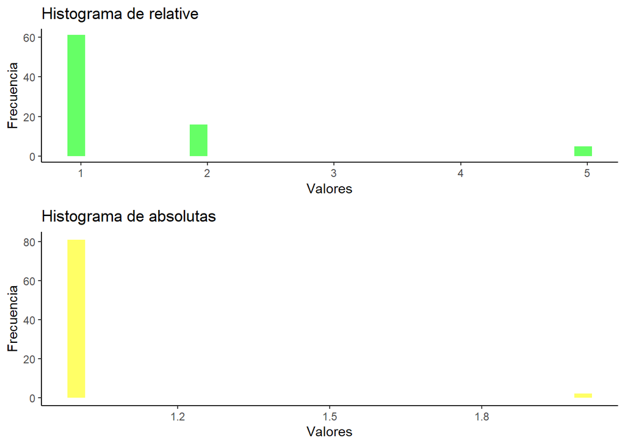

```r
#cargar bibliotecas
library(ggplot2)
library(ggpubr)

# # Crear datos "relative" y "absolutas".
relative <- c(1, 2, 3, 4, 5, 4, 3, 2, 1)
absolutas <- c(2, 4, 6, 8, 10, 8, 6, 4, 2)

relative <- tablax
absolutas <- tablay

#Crear un histograma para visualizar la distribución de "relative".
histo1 <- ggplot(data.frame(x=relative), aes(x=x)) +
  geom_histogram(aes(y=..count..), fill="green", alpha=0.6) +
  labs(title="Histograma de relative", x="Valores", y="Frecuencia")

#Crear  histograma utilizando ggplot para visualizar la distribución de "absolutas".
histo2 <- ggplot(data.frame(x=absolutas), aes(x=x)) +
  geom_histogram(aes(y=..count..), fill="yellow", alpha=0.6) +
  labs(title="Histograma de absolutas", x="Valores", y="Frecuencia")

# mejorar apariencia grafica
theme_set(theme_classic())

#organizar  gráficos en un panel (dos filas y una columna)

ggarrange(histo1, histo2, ncol=1, heights=c(1,1.2))
```

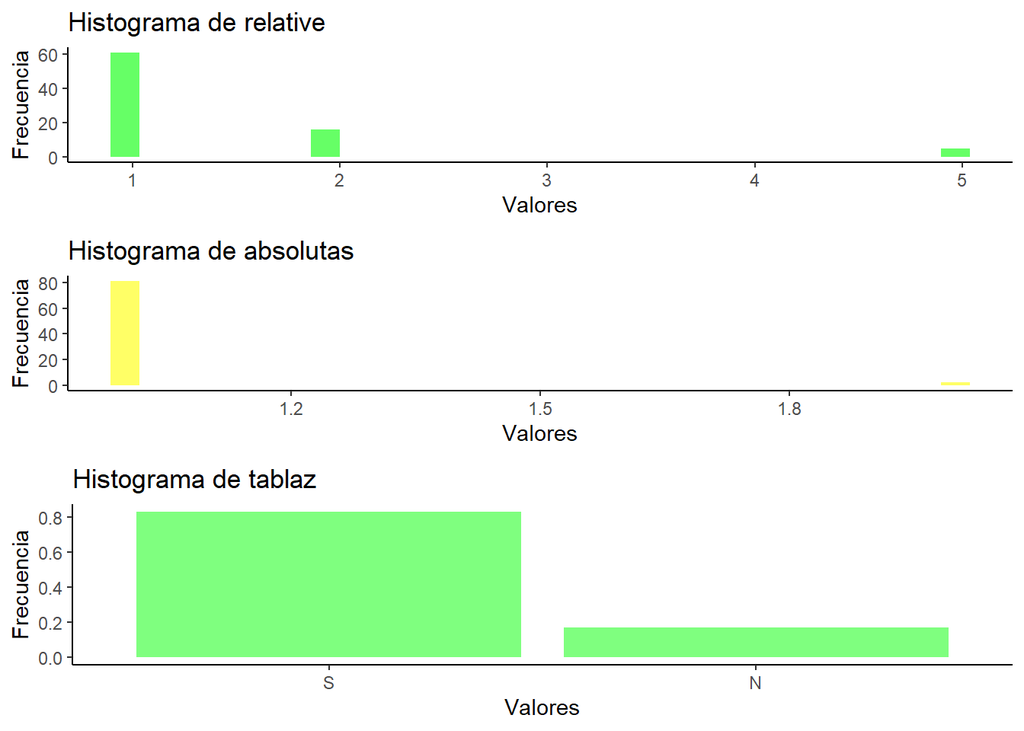

```r
# Restaurar tema x defecto de ggplot2 con theme_gray()
theme_set(theme_gray())

#################
# Cargar las bibliotecas ggplot2 y ggpubr

library(ggplot2)
library(ggpubr)

# Crear datos
relative <- tablax
absolutas <- tablay


# Crear  histograma
histo1 <- ggplot(data.frame(x=relative), aes(x=x)) +
  geom_histogram(aes(y=..count..), fill="green", alpha=0.6) +
  labs(title="Histograma de relative", x="Valores", y="Frecuencia")

# Crear  histograma
histo2 <- ggplot(data.frame(x=absolutas), aes(x=x)) +
  geom_histogram(aes(y=..count..), fill="yellow", alpha=0.6) +
  labs(title="Histograma de absolutas", x="Valores", y="Frecuencia")

# crear histograma
factor_tablaz <- factor(tablaz, levels = c("S", "N"))

#  data frame con la columna "x"
data <- data.frame(x = factor_tablaz)

# Crear el histograma
histo3 <- ggplot(data, aes(x = x)) +
  geom_bar(aes(y=..count../sum(..count..)), fill="green", alpha=0.5, stat = "count") +
  labs(title="Histograma de tablaz", x="Valores", y="Frecuencia")


# mejorar la vista de gráficos
theme_set(theme_classic())

# generar  gráficos con dos filas y una columna usando ggarrange()
ggarrange(histo1, histo2, histo3, ncol=1, heights=c(1,1,1.2))
```

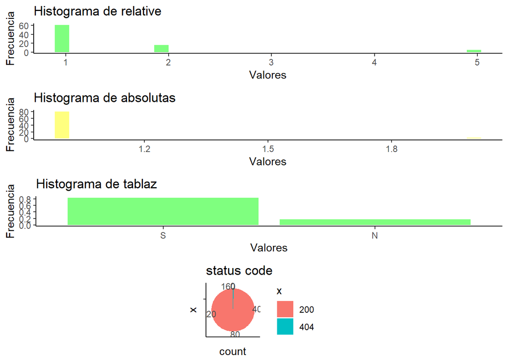

```r
################

library(ggplot2)
library(ggpubr)

# datos
relative <- tablax
absolutas <- tablay


#histograma
histo1 <- ggplot(data.frame(x=relative), aes(x=x)) +
  geom_histogram(aes(y=..count..), fill="green", alpha=0.5) +
  labs(title="Histograma de relative", x="Valores", y="Frecuencia")

#histograma
histo2 <- ggplot(data.frame(x=absolutas), aes(x=x)) +
  geom_histogram(aes(y=..count..), fill="yellow", alpha=0.5) +
  labs(title="Histograma de absolutas", x="Valores", y="Frecuencia")

#histograma
factor_tablaz <- factor(tablaz, levels = c("S", "N"))

# data frame con la columna "x"
data <- data.frame(x = factor_tablaz)

#histograma
histo3 <- ggplot(data, aes(x = x)) +
  geom_bar(aes(y=..count../sum(..count..)), fill="green", alpha=0.5, stat = "count") +
  labs(title="Histograma de tablaz", x="Valores", y="Frecuencia")

histo4 <- ggplot(data.frame(x=tablar), aes(x= "", fill = x)) +
  geom_bar(width = 1) + coord_polar(theta = "y") +
  labs(title="status code")

#  apariencia
theme_set(theme_classic())

# ordenar  gráficos en dos filas y una columna
ggarrange(histo1, histo2, histo3, histo4, ncol=1, heights=c(1,1,1,1.2))
```